# Mobility - Walking

# 1 Description of DataSchema variable

The description of harmonised variable is the following:

- Short name: `mob_walk`
- Variable label: `Mobility - walking`
- Variable description: `Difficulty for walking by yourself and without using any special equipment`
- Domain: `Health status and functional limitations`
- Value type: `categorical`
- Category coding:

| **Code** | **Category Label** |
| --- | --- |
| 0 | Yes |
| 1 | No |

- Category missings:

| **Code** | **Category Label** |
| --- | --- |
| 991 | CAPI/interviewer error |
| 992 | Impute |
| 993 | Disable to measure |
| 994 | Not attempt/not done |
| 995 | Does not answer |
| 996 | Not applicable |
| 997 | Refuse |
| 998 | Do not know |
| 999 | Missing |

# 2 Data process

## 2.1 England

### 2.1.1 Wave 1

#### 2.1.1.1 Study-specific variable description

| **Name** | `hefunc` | `hemobwa` |
| --- | --- | --- |
| **Label** | `By yourself and without using any special equipment, how much difficulty do you have walking for a quarter of a mile?` | `mobility: difficulty walking 100 yards` |
| **Table name** | `wave_1_core_data_v3` | `wave_1_ifs_derived_variables` |
| **Categories** | `1 = ... no difficulty; 2 = some difficulty; 3 = much difficulty; 4 = or, are you unable to do this?` | `0 = No; 1 = Yes` |
| **Missings** | `-9 = Refusal; -8 = Don't Know; -1 = Not applicable` | `-9 = refuse; -8 = don't know; -1 = inapplicable` |
| **Description** |  |  |

hefunc

| Sample size | Missing values |
| --- | --- |
| 12099 | 195 |

Category

|  | 1 | 2 | 3 | 4 |
| --- | --- | --- | --- | --- |
| Frequency | 8521.00 | 1539.00 | 689.00 | 1155.00 |
| Percentage | 70.43 | 12.72 | 5.69 | 9.55 |

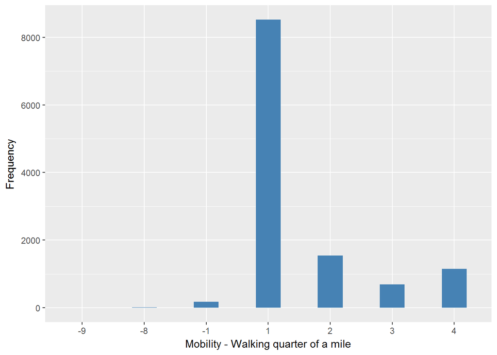

hemobwa

| Sample size | Missing values |
| --- | --- |
| 12099 | 191 |

Category

|  | 0 | 1 |
| --- | --- | --- |
| Frequency | 10452.00 | 1456.00 |
| Percentage | 86.39 | 12.03 |

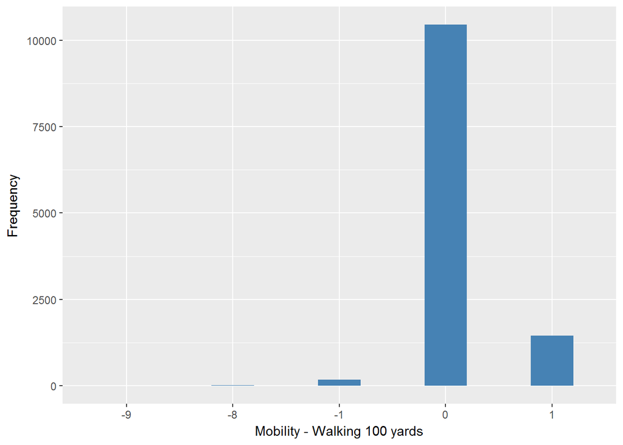

#### 2.1.1.2 Harmonisation algorithm

To compute the harmonize variable from the study-specific variable it has to be recoded as follows:

- `((hefunc==-9))&(hemobwa==-9) into 997`
- `(hefunc==-8)&(hemobwa==-8) into 998`
- `((hefunc==-1))&(hemobwa==-1) into 996`
- `(hefunc==1) & (hemobwa!=1) into 1`
- `((hefunc==-9)|(hefunc==-8))&(hemobwa==0) into 1`
- `Otherwise<-0`

**R script:**

```r
ELSA_ds_w1 <- tibble(id = ELSA_w1_mob_walk$id)
ELSA_ds_w1$mob_walk <- rep(0, length(ELSA_w1_mob_walk$id))
ELSA_ds_w1$mob_walk[((ELSA_w1_mob_walk$hefunc == 1) & (ELSA_w1_mob_walk$hemobwa !=
    1))] <- 1
ELSA_ds_w1$mob_walk[(((ELSA_w1_mob_walk$hefunc == -9) | (ELSA_w1_mob_walk$hefunc ==
    -8)) & (ELSA_w1_mob_walk$hemobwa == 0))] <- 1
ELSA_ds_w1$mob_walk[(((ELSA_w1_mob_walk$hefunc == -1)) & (ELSA_w1_mob_walk$hemobwa ==
    -1))] <- 996
ELSA_ds_w1$mob_walk[((ELSA_w1_mob_walk$hefunc == -9) & (ELSA_w1_mob_walk$hemobwa ==
    -9))] <- 997
ELSA_ds_w1$mob_walk[((ELSA_w1_mob_walk$hefunc == -8) & (ELSA_w1_mob_walk$hemobwa ==
    -8))] <- 998

ELSA_ds_w1$mob_walk <- labelled(ELSA_ds_w1$mob_walk, labels = c(Yes = 0, No = 1,
    Not_applicable = 996, Refuse = 997, Do_not_know = 998))
```

#### 2.1.1.3 Statistical description of the new harmonised variable

mob_walk

| Sample size | Missing values |
| --- | --- |
| 12099 | 188 |

Category

|  | 0 | 1 |
| --- | --- | --- |
| Frequency | 3401.00 | 8510.00 |
| Percentage | 28.11 | 70.34 |

Type of missing

|  | 991 | 992 | 993 | 994 | 995 | 996 | 997 | 998 | 999 | NA |
| --- | --- | --- | --- | --- | --- | --- | --- | --- | --- | --- |
| Frequency | 0 | 0 | 0 | 0 | 0 | 175.00 | 4.00 | 9.00 | 0 | 0 |
| Percentage | 0 | 0 | 0 | 0 | 0 | 1.45 | 0.03 | 0.07 | 0 | 0 |

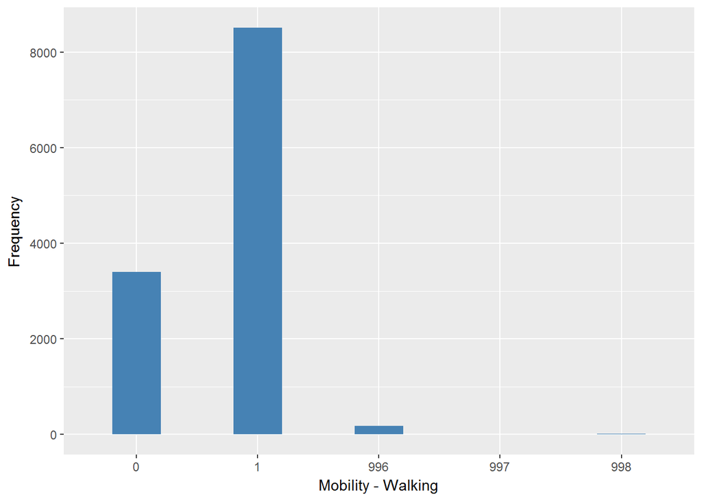

#### 2.1.1.4 Validation

|  | Otherwise -> 0 | ((hefunc=1&hemobwa!=1)\|(hefunc=-9 or -8&hemobwa=0))->1 | (hefunc=-1 or -9&hemobwa=-1)->996 | (hefunc=-9&hemobwa=-9)->997 | (hefunc=-8&hemobwa=-8)->998 |
| --- | --- | --- | --- | --- | --- |
| combi | 3401 | 8510 | 175 | 4 | 9 |
|  | 3401 | 8510 | 175 | 4 | 9 |

### 2.1.2 Wave 2

#### 2.1.2.1 Study-specific variable description

| **Name** | `HeFunc` | `hemobwa` |
| --- | --- | --- |
| **Label** | `Difficulty walking 1/4 mile unaided` | `mobility: difficulty walking 100 yards` |
| **Table name** | `wave_2_core_data_v4` | `wave_2_ifs_derived_variables` |
| **Categories** | `1 = ... no difficulty; 2 = some difficulty; 3 = much difficulty; 4 = Unable to do this` | `0 = No; 1 = Yes` |
| **Missings** | `-9 = Refusal; -8 = Don't Know` | `-9 = refuse; -8 = don't know` |
| **Description** |  |  |

HeFunc

| Sample size | Missing values |
| --- | --- |
| 9432 | 9 |

Category

|  | 1 | 2 | 3 | 4 |
| --- | --- | --- | --- | --- |
| Frequency | 6701.00 | 1217.0 | 608.00 | 897.00 |
| Percentage | 71.05 | 12.9 | 6.45 | 9.51 |

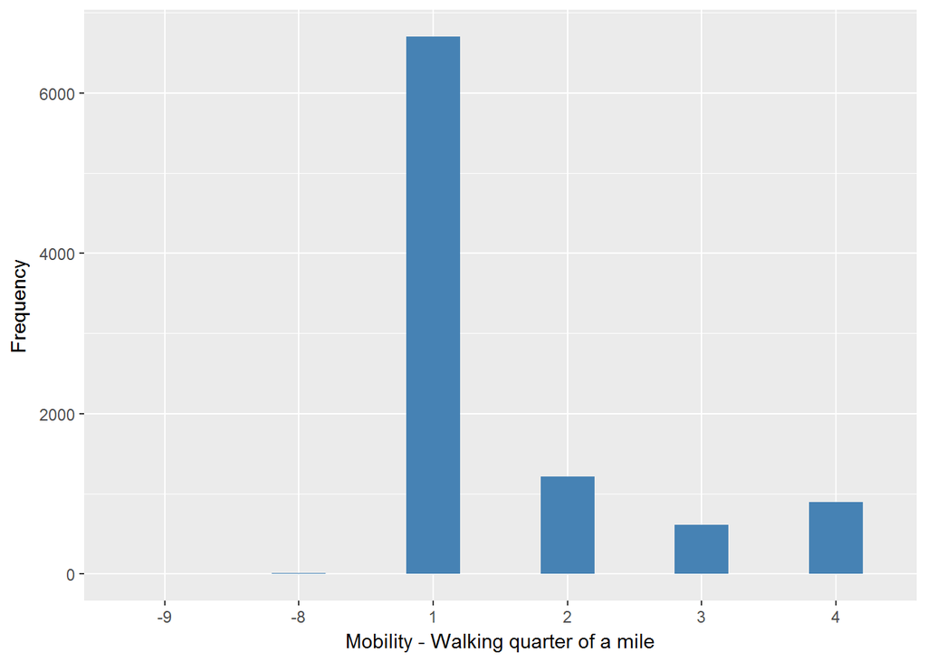

hemobwa

| Sample size | Missing values |
| --- | --- |
| 9432 | 3 |

Category

|  | 0 | 1 |
| --- | --- | --- |
| Frequency | 8252.00 | 1177.00 |
| Percentage | 87.49 | 12.48 |

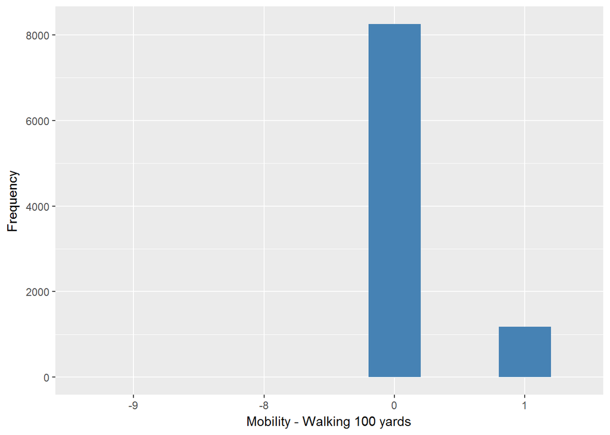

#### 2.1.2.2 Harmonisation algorithm

To compute the harmonize variable from the study-specific variable it has to be recoded as follows:

- `((hefunc==-9))&(hemobwa==-9) into 997`
- `(hefunc==-8)&(hemobwa==-8) into 998`
- `(hefunc==1) & (hemobwa!=1) into 1`
- `((hefunc==-9)|(hefunc==-8))&(hemobwa==0) into 1`
- `Otherwise<-0`

**R script:**

```r
ELSA_ds_w2 <- tibble(id = ELSA_w2_mob_walk$id)
ELSA_ds_w2$mob_walk <- rep(0, length(ELSA_w2_mob_walk$id))
ELSA_ds_w2$mob_walk[((ELSA_w2_mob_walk$HeFunc == 1) & (ELSA_w2_mob_walk$hemobwa !=
    1))] <- 1
ELSA_ds_w2$mob_walk[(((ELSA_w2_mob_walk$HeFunc == -9) | (ELSA_w2_mob_walk$HeFunc ==
    -8)) & (ELSA_w2_mob_walk$hemobwa == 0))] <- 1
ELSA_ds_w2$mob_walk[((ELSA_w2_mob_walk$HeFunc == -9) & (ELSA_w2_mob_walk$hemobwa ==
    -9))] <- 997
ELSA_ds_w2$mob_walk[((ELSA_w2_mob_walk$HeFunc == -8) & (ELSA_w2_mob_walk$hemobwa ==
    -8))] <- 998

ELSA_ds_w2$mob_walk <- labelled(ELSA_ds_w2$mob_walk, labels = c(Yes = 0, No = 1,
    Not_applicable = 996, Refuse = 997, Do_not_know = 998))
```

#### 2.1.2.3 Statistical description of the new harmonised variable

mob_walk

| Sample size | Missing values |
| --- | --- |
| 9432 | 2 |

Category

|  | 0 | 1 |
| --- | --- | --- |
| Frequency | 2749.00 | 6681.00 |
| Percentage | 29.15 | 70.83 |

Type of missing

|  | 991 | 992 | 993 | 994 | 995 | 996 | 997 | 998 | 999 | NA |
| --- | --- | --- | --- | --- | --- | --- | --- | --- | --- | --- |
| Frequency | 0 | 0 | 0 | 0 | 0 | 0 | 1.00 | 1.00 | 0 | 0 |
| Percentage | 0 | 0 | 0 | 0 | 0 | 0 | 0.01 | 0.01 | 0 | 0 |

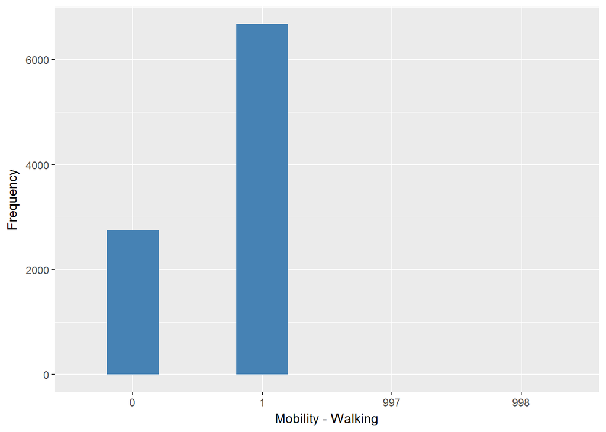

#### 2.1.2.4 Validation

|  | Otherwise -> 0 | ((hefunc=1&hemobwa!=1)\|(hefunc=-9 or -8&hemobwa=0))->1 | (hefunc=-9&hemobwa=-9)->997 | (hefunc=-8&hemobwa=-8)->998 |
| --- | --- | --- | --- | --- |
| combi | 2749 | 6681 | 1 | 1 |
|  | 2749 | 6681 | 1 | 1 |

### 2.1.3 Wave 3

#### 2.1.3.1 Study-specific variable description

| **Name** | `hefunc` | `hemobwa` |
| --- | --- | --- |
| **Label** | `By yourself and without using any special equipment, how much difficulty do you have walking for a quarter of a mile?` | `Mobility: difficulty walking 100 yards` |
| **Table name** | `wave_3_elsa_data_v4` | `wave_3_elsa_data_v4` |
| **Categories** | `1 = No difficulty; 2 = Some difficulty; 3 = Much difficulty; 4 = or, are you unable to do this?` | `0 = No; 1 = Yes` |
| **Missings** | `-9 = Refusal; -8 = Don't Know` | `-1 = Not applicable` |
| **Description** |  |  |

hefunc

| Sample size | Missing values |
| --- | --- |
| 9771 | 5 |

Category

|  | 1 | 2 | 3 | 4 |
| --- | --- | --- | --- | --- |
| Frequency | 7048.00 | 1202.0 | 576.00 | 940.00 |
| Percentage | 72.13 | 12.3 | 5.89 | 9.62 |

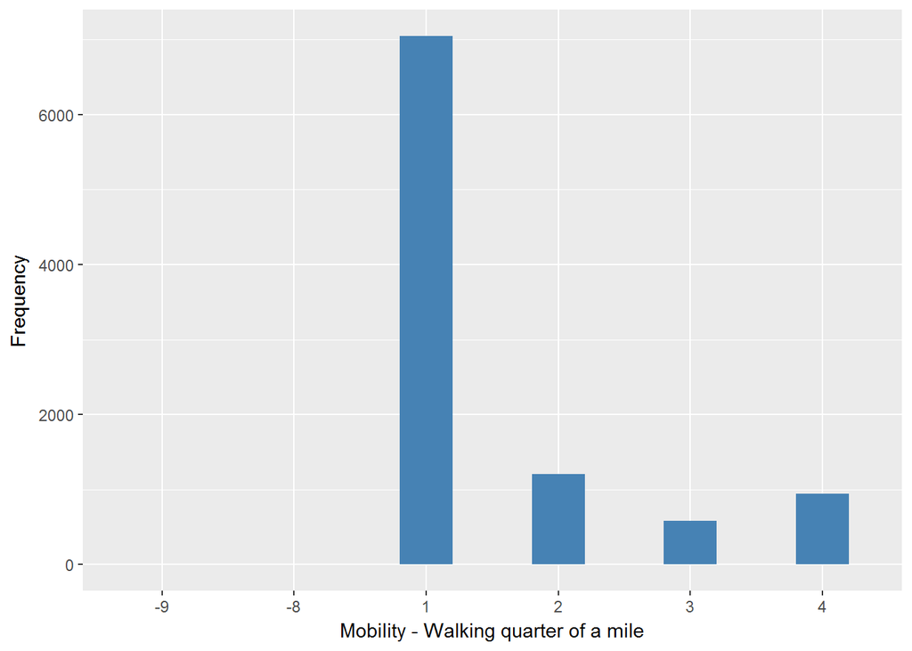

hemobwa

| Sample size | Missing values |
| --- | --- |
| 9771 | 4 |

Category

|  | 0 | 1 |
| --- | --- | --- |
| Frequency | 8586.00 | 1181.00 |
| Percentage | 87.87 | 12.09 |

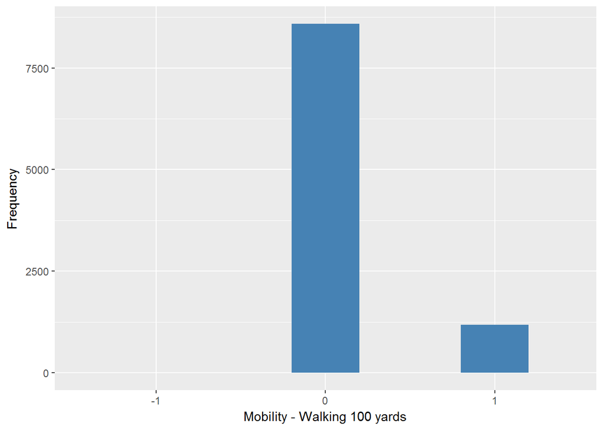

#### 2.1.3.2 Harmonisation algorithm

To compute the harmonize variable from the study-specific variable it has to be recoded as follows:

- `(hefunc==1) & (hemobwa!=1) into 1`
- `((hefunc==-9)|(hefunc==-8))&(hemobwa==0) into 1`
- `((hefunc==-1)|(hefunc==-9))&(hemobwa==-1) into 996`
- `Otherwise<-0`

**R script:**

```r
ELSA_ds_w3 <- tibble(id = ELSA_w3_mob_walk$id)
ELSA_ds_w3$mob_walk <- rep(0, length(ELSA_w3_mob_walk$id))
ELSA_ds_w3$mob_walk[((ELSA_w3_mob_walk$hefunc == 1) & (ELSA_w3_mob_walk$hemobwa !=
    1))] <- 1
ELSA_ds_w3$mob_walk[(((ELSA_w3_mob_walk$hefunc == -9) | (ELSA_w3_mob_walk$hefunc ==
    -8)) & (ELSA_w3_mob_walk$hemobwa == 0))] <- 1
ELSA_ds_w3$mob_walk[(((ELSA_w3_mob_walk$hefunc == -1) | (ELSA_w3_mob_walk$hefunc ==
    -9)) & (ELSA_w3_mob_walk$hemobwa == -1))] <- 996
ELSA_ds_w3$mob_walk <- labelled(ELSA_ds_w3$mob_walk, labels = c(Yes = 0, No = 1,
    Not_applicable = 996, Refuse = 997, Do_not_know = 998))
```

#### 2.1.3.3 Statistical description of the new harmonised variable

mob_walk

| Sample size | Missing values |
| --- | --- |
| 9771 | 1 |

Category

|  | 0 | 1 |
| --- | --- | --- |
| Frequency | 2746.0 | 7024.00 |
| Percentage | 28.1 | 71.89 |

Type of missing

|  | 991 | 992 | 993 | 994 | 995 | 996 | 997 | 998 | 999 | NA |
| --- | --- | --- | --- | --- | --- | --- | --- | --- | --- | --- |
| Frequency | 0 | 0 | 0 | 0 | 0 | 1.00 | 0 | 0 | 0 | 0 |
| Percentage | 0 | 0 | 0 | 0 | 0 | 0.01 | 0 | 0 | 0 | 0 |

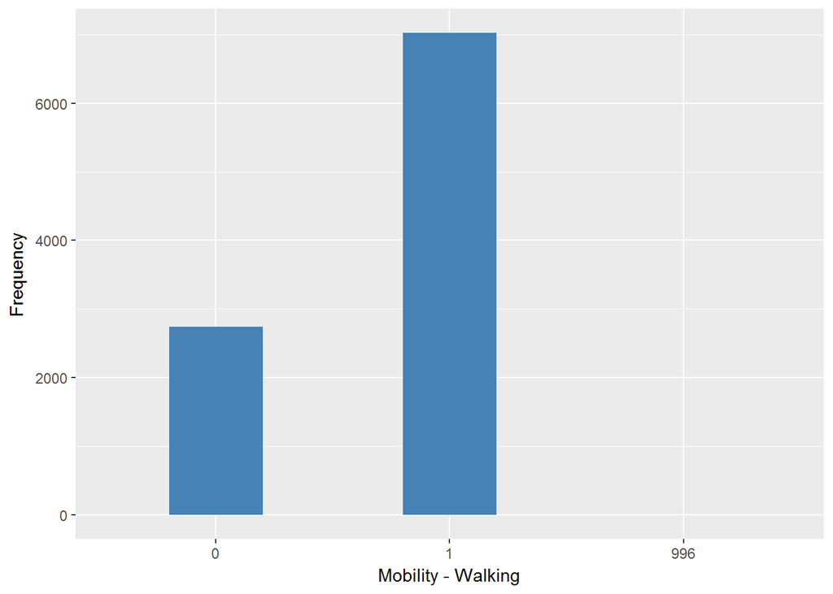

#### 2.1.3.4 Validation

|  | Otherwise -> 0 | ((hefunc=1&hemobwa!=1)\|(hefunc=-9 or -8&hemobwa=0))->1 | (hefunc=-1 or -9&hemobwa=-1)->996 |
| --- | --- | --- | --- |
| combi | 2746 | 7024 | 1 |
|  | 2746 | 7024 | 1 |

### 2.1.4 Wave 4

#### 2.1.4.1 Study-specific variable description

| **Name** | `hefunc` | `hemobwa` |
| --- | --- | --- |
| **Label** | `By yourself and without using any special equipment, how much difficulty do you have walking for a quarter of a mile?` | `Mobility: difficulty walking 100 yards` |
| **Table name** | `wave_4_elsa_data_v3` | `wave_4_elsa_data_v3` |
| **Categories** | `1 = No difficulty; 2 = Some difficulty; 3 = Much difficulty; 4 = or, are you unable to do this?` | `0 = No; 1 = Yes` |
| **Missings** | `-9 = Refusal; -8 = Don't Know` | `-9 = Refusal; -8 = Don't Know` |
| **Description** |  |  |

hefunc

| Sample size | Missing values |
| --- | --- |
| 11050 | 9 |

Category

|  | 1 | 2 | 3 | 4 |
| --- | --- | --- | --- | --- |
| Frequency | 7949.00 | 1371.00 | 665.00 | 1056.00 |
| Percentage | 71.94 | 12.41 | 6.02 | 9.56 |

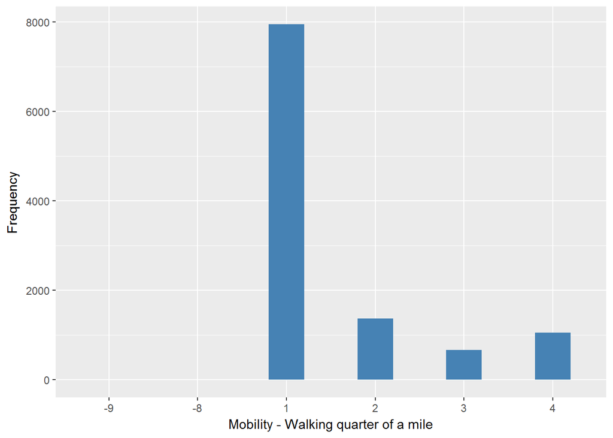

hemobwa

| Sample size | Missing values |
| --- | --- |
| 11050 | 10 |

Category

|  | 0 | 1 |
| --- | --- | --- |
| Frequency | 9723.00 | 1317.00 |
| Percentage | 87.99 | 11.92 |

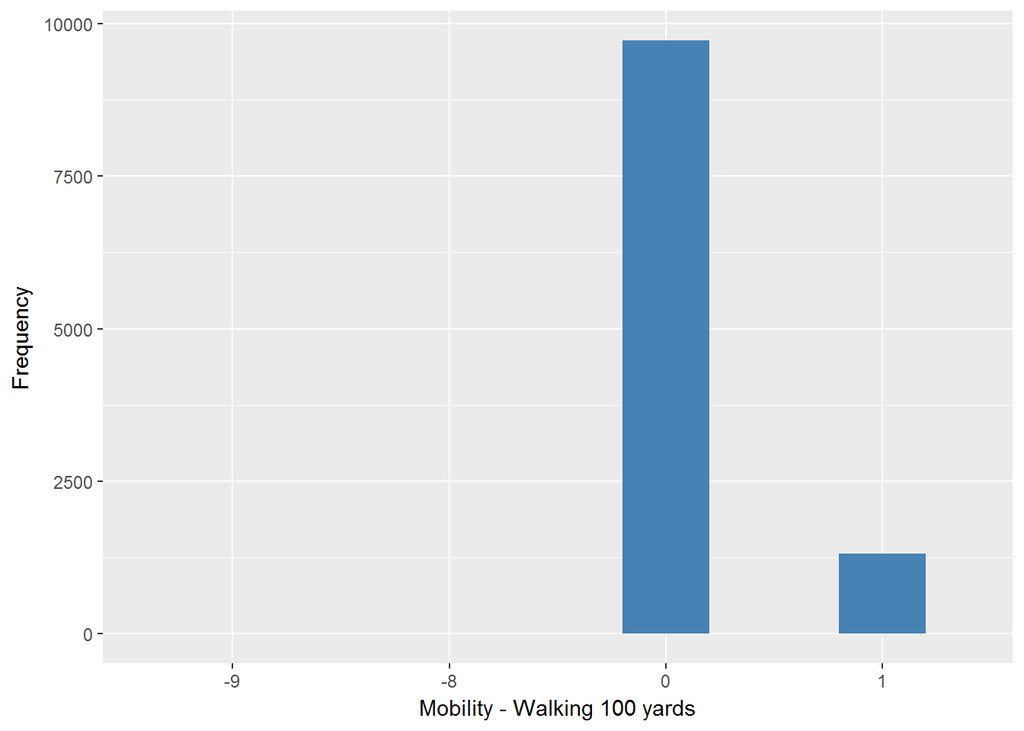

#### 2.1.4.2 Harmonisation algorithm

To compute the harmonize variable from the study-specific variable it has to be recoded as follows:

- `(hefunc==1) & (hemobwa!=1)into 1`
- `((hefunc==-9)|(hefunc==-8))&(hemobwa==0) into 1`
- `(hefunc==-9)&(hemobwa==-9) into 997`
- `(hefunc==-8)&(hemobwa==-8) into 998`
- `Otherwise<-0`

**R script:**

```r
ELSA_ds_w4 <- tibble(id = ELSA_w4_mob_walk$id)
ELSA_ds_w4$mob_walk <- rep(0, length(ELSA_w4_mob_walk$id))
ELSA_ds_w4$mob_walk[((ELSA_w4_mob_walk$hefunc == 1) & (ELSA_w4_mob_walk$hemobwa !=
    1))] <- 1
ELSA_ds_w4$mob_walk[(((ELSA_w4_mob_walk$hefunc == -9) | (ELSA_w4_mob_walk$hefunc ==
    -8)) & (ELSA_w4_mob_walk$hemobwa == 0))] <- 1
ELSA_ds_w4$mob_walk[((ELSA_w4_mob_walk$hefunc == -9) & (ELSA_w4_mob_walk$hemobwa ==
    -9))] <- 997
ELSA_ds_w4$mob_walk[((ELSA_w4_mob_walk$hefunc == -8) & (ELSA_w4_mob_walk$hemobwa ==
    -8))] <- 998
ELSA_ds_w4$mob_walk <- labelled(ELSA_ds_w4$mob_walk, labels = c(Yes = 0, No = 1,
    Not_applicable = 996, Refuse = 997, Do_not_know = 998))
```

#### 2.1.4.3 Statistical description of the new harmonised variable

mob_walk

| Sample size | Missing values |
| --- | --- |
| 11050 | 8 |

Category

|  | 0 | 1 |
| --- | --- | --- |
| Frequency | 3105.0 | 7937.00 |
| Percentage | 28.1 | 71.83 |

Type of missing

|  | 991 | 992 | 993 | 994 | 995 | 996 | 997 | 998 | 999 | NA |
| --- | --- | --- | --- | --- | --- | --- | --- | --- | --- | --- |
| Frequency | 0 | 0 | 0 | 0 | 0 | 0 | 6.00 | 2.00 | 0 | 0 |
| Percentage | 0 | 0 | 0 | 0 | 0 | 0 | 0.05 | 0.02 | 0 | 0 |

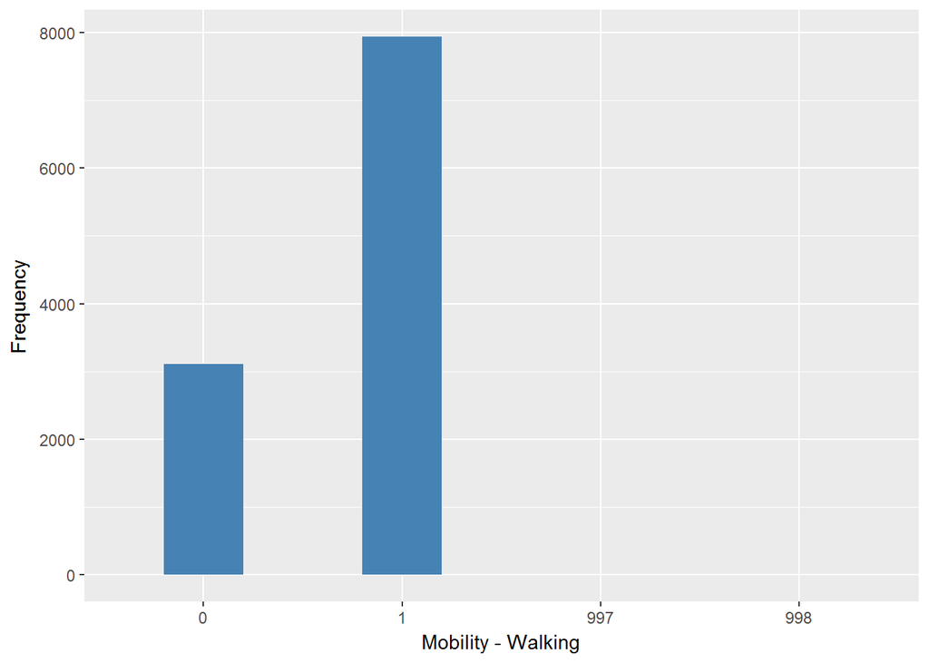

#### 2.1.4.4 Validation

|  | Otherwise -> 0 | ((hefunc=1&hemobwa!=1)\|(hefunc=-9 or -8&hemobwa=0))->1 | (hefunc=-9&hemobwa=-9)->997 | (hefunc=-8&hemobwa=-8)->998 |
| --- | --- | --- | --- | --- |
| combi | 3105 | 7937 | 6 | 2 |
|  | 3105 | 7937 | 6 | 2 |

### 2.1.5 Wave 5

#### 2.1.5.1 Study-specific variable description

| **Name** | `HeFunc` | `hemobwa` |
| --- | --- | --- |
| **Label** | `By yourself and without using any special equipment, how much difficulty do you have walking for a quarter of a mile?` | `Mobility: difficulty walking 100 yards` |
| **Table name** | `wave_5_elsa_data_v4` | `wave_5_elsa_data_v4` |
| **Categories** | `1 = No difficulty; 2 = Some difficulty; 3 = Much difficulty; 4 = or, are you unable to do this?` | `0 = No; 1 = Yes` |
| **Missings** | `-9 = Refusal; -8 = Don't Know` | `-9 = Refusal; -8 = Don't Know` |
| **Description** |  |  |

HeFunc

| Sample size | Missing values |
| --- | --- |
| 10274 | 13 |

Category

|  | 1 | 2 | 3 | 4 |
| --- | --- | --- | --- | --- |
| Frequency | 7167.00 | 1308.00 | 647.0 | 1139.00 |
| Percentage | 69.76 | 12.73 | 6.3 | 11.09 |

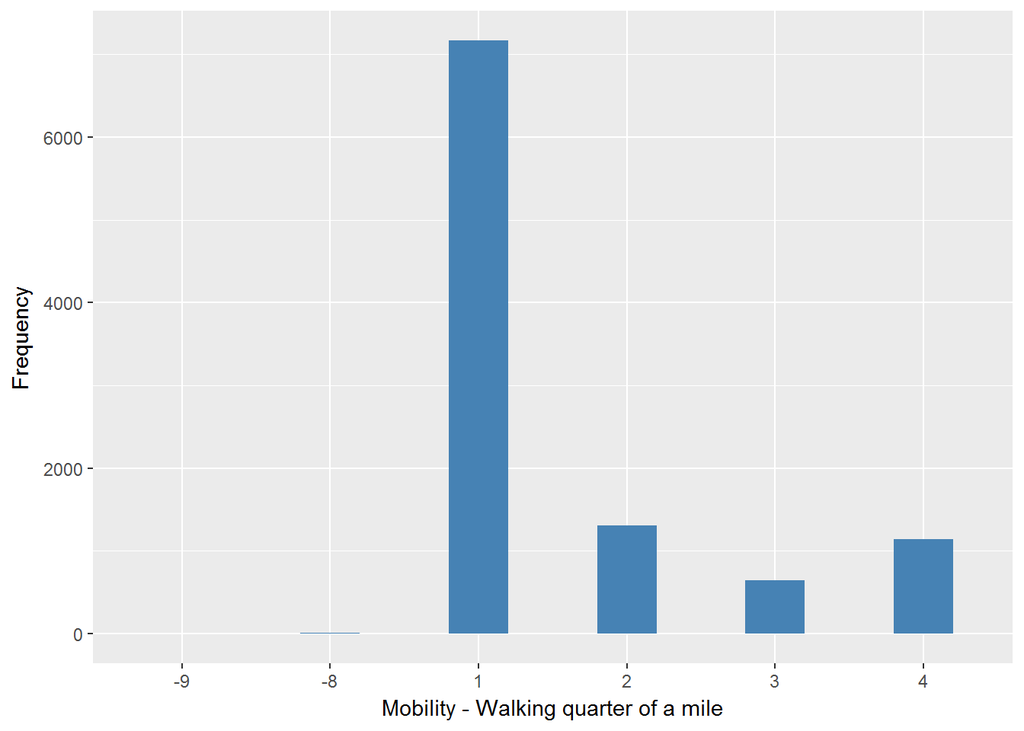

hemobwa

| Sample size | Missing values |
| --- | --- |
| 10274 | 9 |

Category

|  | 0 | 1 |
| --- | --- | --- |
| Frequency | 8870.00 | 1395.00 |
| Percentage | 86.33 | 13.58 |

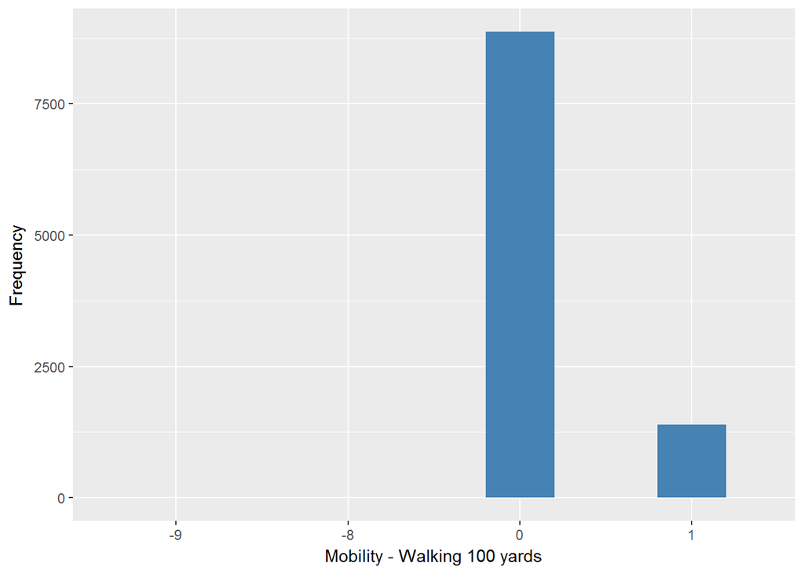

#### 2.1.5.2 Harmonisation algorithm

To compute the harmonize variable from the study-specific variable it has to be recoded as follows:

- `(hefunc==1) & (hemobwa!=1)into 1`
- `((hefunc==-9)|(hefunc==-8))&(hemobwa==0) into 1`
- `((hefunc==-9)|(hefunc==-8))&(hemobwa==-9) into 997`
- `(hefunc==-8)&(hemobwa==-8) into 998`
- `Otherwise<-0`

**R script:**

```r
ELSA_ds_w5 <- tibble(id = ELSA_w5_mob_walk$id)
ELSA_ds_w5$mob_walk <- rep(0, length(ELSA_w5_mob_walk$id))
ELSA_ds_w5$mob_walk[((ELSA_w5_mob_walk$HeFunc == 1) & (ELSA_w5_mob_walk$hemobwa !=
    1))] <- 1
ELSA_ds_w5$mob_walk[(((ELSA_w5_mob_walk$HeFunc == -9) | (ELSA_w5_mob_walk$HeFunc ==
    -8)) & (ELSA_w5_mob_walk$hemobwa == 0))] <- 1
ELSA_ds_w5$mob_walk[(((ELSA_w5_mob_walk$HeFunc == -9) | (ELSA_w5_mob_walk$HeFunc ==
    -8)) & (ELSA_w5_mob_walk$hemobwa == -9))] <- 997
ELSA_ds_w5$mob_walk[((ELSA_w5_mob_walk$HeFunc == -8) & (ELSA_w5_mob_walk$hemobwa ==
    -8))] <- 998
ELSA_ds_w5$mob_walk <- labelled(ELSA_ds_w5$mob_walk, labels = c(Yes = 0, No = 1,
    Not_applicable = 996, Refuse = 997, Do_not_know = 998))
```

#### 2.1.5.3 Statistical description of the new harmonised variable

mob_walk

| Sample size | Missing values |
| --- | --- |
| 10274 | 7 |

Category

|  | 0 | 1 |
| --- | --- | --- |
| Frequency | 3121.00 | 7146.00 |
| Percentage | 30.38 | 69.55 |

Type of missing

|  | 991 | 992 | 993 | 994 | 995 | 996 | 997 | 998 | 999 | NA |
| --- | --- | --- | --- | --- | --- | --- | --- | --- | --- | --- |
| Frequency | 0 | 0 | 0 | 0 | 0 | 0 | 4.00 | 3.00 | 0 | 0 |
| Percentage | 0 | 0 | 0 | 0 | 0 | 0 | 0.04 | 0.03 | 0 | 0 |

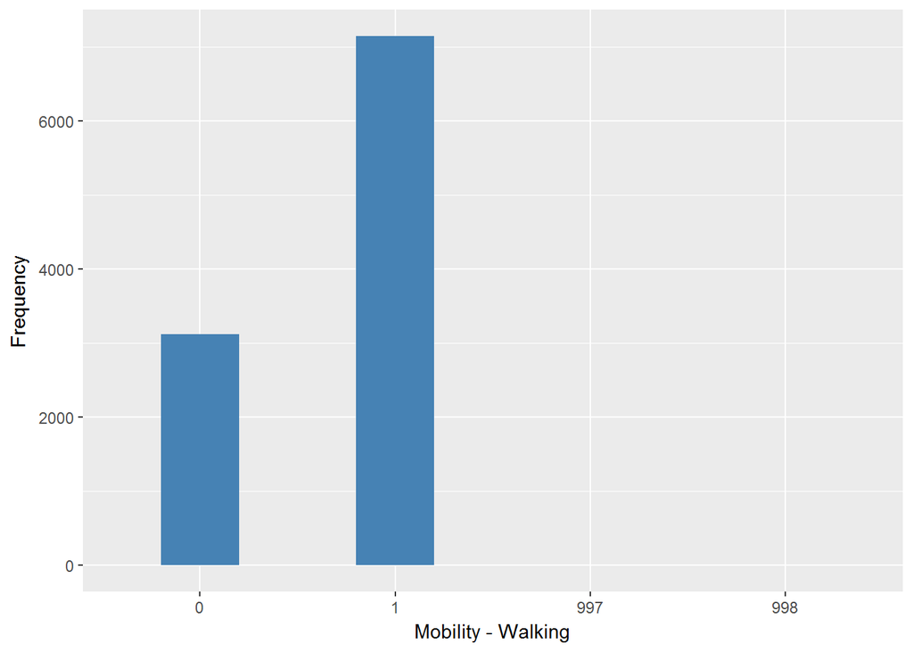

#### 2.1.5.4 Validation

|  | Otherwise -> 0 | ((hefunc=1&hemobwa!=1)\|(hefunc=-9 or -8&hemobwa=0))->1 | (hefunc=-9 or -8&hemobwa=-9)->997 | (hefunc=-8&hemobwa=-8)->998 |
| --- | --- | --- | --- | --- |
| combi | 3121 | 7146 | 4 | 3 |
|  | 3121 | 7146 | 4 | 3 |

### 2.1.6 Wave 6

#### 2.1.6.1 Study-specific variable description

| **Name** | `HeFunc` | `hemobwa` |
| --- | --- | --- |
| **Label** | `By yourself and without using any special equipment, how much difficulty do you have walking for a quarter of a mile?` | `Mobility: difficulty walking 100 yards` |
| **Table name** | `wave_6_elsa_data_v2` | `wave_6_elsa_data_v2` |
| **Categories** | `1 = No difficulty; 2 = Some difficulty; 3 = Much difficulty; 4 = or, are you unable to do this?` | `0 = No; 1 = Yes` |
| **Missings** | `-9 = Refusal; -8 = Don't Know` | `-9 = Refusal; -8 = Don't Know` |
| **Description** |  |  |

HeFunc

| Sample size | Missing values |
| --- | --- |
| 10601 | 4 |

Category

|  | 1 | 2 | 3 | 4 |
| --- | --- | --- | --- | --- |
| Frequency | 7528.00 | 1303.00 | 644.00 | 1122.00 |
| Percentage | 71.01 | 12.29 | 6.07 | 10.58 |

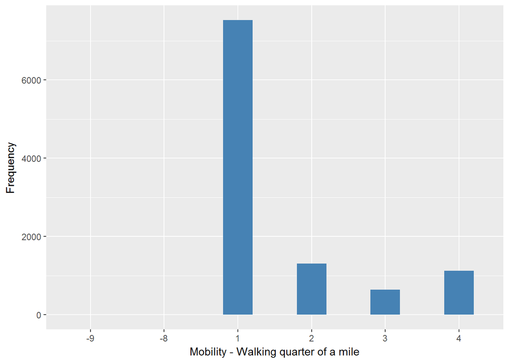

hemobwa

| Sample size | Missing values |
| --- | --- |
| 10601 | 5 |

Category

|  | 0 | 1 |
| --- | --- | --- |
| Frequency | 9145.00 | 1451.00 |
| Percentage | 86.27 | 13.69 |

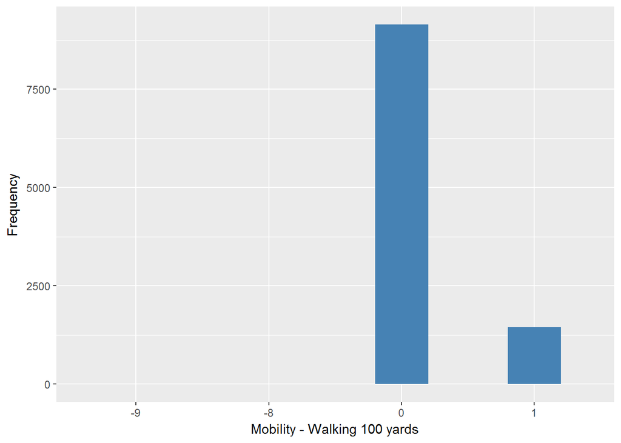

#### 2.1.6.2 Harmonisation algorithm

To compute the harmonize variable from the study-specific variable it has to be recoded as follows:

- `(hefunc==1) & (hemobwa!=1)into 1`
- `((hefunc==-9)|(hefunc==-8))&(hemobwa==0) into 1`
- `(hefunc==-9)&(hemobwa==-9) into 997`
- `(hefunc==-8)&(hemobwa==-8) into 998`
- `Otherwise<-0`

**R script:**

```r
ELSA_ds_w6 <- tibble(id = ELSA_w6_mob_walk$id)
ELSA_ds_w6$mob_walk <- rep(0, length(ELSA_w6_mob_walk$id))
ELSA_ds_w6$mob_walk[((ELSA_w6_mob_walk$HeFunc == 1) & (ELSA_w6_mob_walk$hemobwa !=
    1))] <- 1
ELSA_ds_w6$mob_walk[(((ELSA_w6_mob_walk$HeFunc == -9) | (ELSA_w6_mob_walk$HeFunc ==
    -8)) & (ELSA_w6_mob_walk$hemobwa == 0))] <- 1
ELSA_ds_w6$mob_walk[((ELSA_w6_mob_walk$HeFunc == -9) & (ELSA_w6_mob_walk$hemobwa ==
    -9))] <- 997
ELSA_ds_w6$mob_walk[((ELSA_w6_mob_walk$HeFunc == -8) & (ELSA_w6_mob_walk$hemobwa ==
    -8))] <- 998
ELSA_ds_w6$mob_walk <- labelled(ELSA_ds_w6$mob_walk, labels = c(Yes = 0, No = 1,
    Not_applicable = 996, Refuse = 997, Do_not_know = 998))
```

#### 2.1.6.3 Statistical description of the new harmonised variable

mob_walk

| Sample size | Missing values |
| --- | --- |
| 10601 | 2 |

Category

|  | 0 | 1 |
| --- | --- | --- |
| Frequency | 3090.00 | 7509.00 |
| Percentage | 29.15 | 70.83 |

Type of missing

|  | 991 | 992 | 993 | 994 | 995 | 996 | 997 | 998 | 999 | NA |
| --- | --- | --- | --- | --- | --- | --- | --- | --- | --- | --- |
| Frequency | 0 | 0 | 0 | 0 | 0 | 0 | 2.00 | 0 | 0 | 0 |
| Percentage | 0 | 0 | 0 | 0 | 0 | 0 | 0.02 | 0 | 0 | 0 |

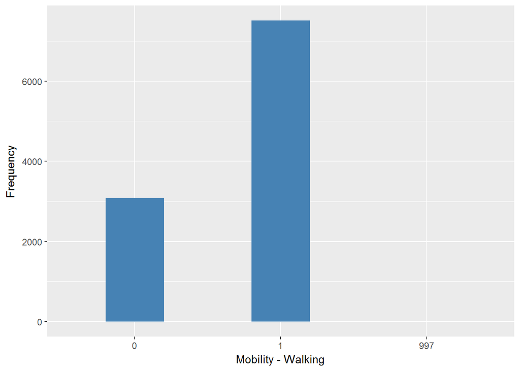

#### 2.1.6.4 Validation

|  | Otherwise -> 0 | ((hefunc=1&hemobwa!=1)\|(hefunc=-9 or -8&hemobwa=0))->1 | (hefunc=-9&hemobwa=-9)->997 |
| --- | --- | --- | --- |
| combi | 3090 | 7509 | 2 |
|  | 3090 | 7509 | 2 |

### 2.1.7 Wave 7

#### 2.1.7.1 Study-specific variable description

| **Name** | `HeFunc` | `hemobwa` |
| --- | --- | --- |
| **Label** | `By yourself and without using any special equipment, how much difficulty do you have walking for a quarter of a mile?` | `Mobility: difficulty walking 100 yards` |
| **Table name** | `wave_7_elsa_data` | `wave_7_elsa_data` |
| **Categories** | `1 = No difficulty; 2 = Some difficulty; 3 = Much difficulty; 4 = or, are you unable to do this?` | `0 = No; 1 = Yes` |
| **Missings** | `-9 = Refusal; -8 = Don't Know` | `-9 = Refusal; -8 = Don't Know` |
| **Description** |  |  |

HeFunc

| Sample size | Missing values |
| --- | --- |
| 9666 | 2 |

Category

|  | 1 | 2 | 3 | 4 |
| --- | --- | --- | --- | --- |
| Frequency | 6942.00 | 1121.0 | 588.00 | 1013.00 |
| Percentage | 71.82 | 11.6 | 6.08 | 10.48 |

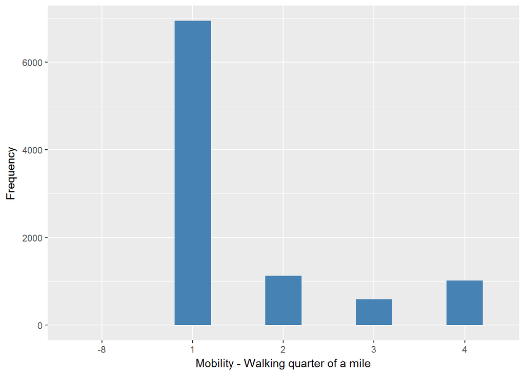

hemobwa

| Sample size | Missing values |
| --- | --- |
| 9666 | 2 |

Category

|  | 0 | 1 |
| --- | --- | --- |
| Frequency | 8386.00 | 1278.00 |
| Percentage | 86.76 | 13.22 |

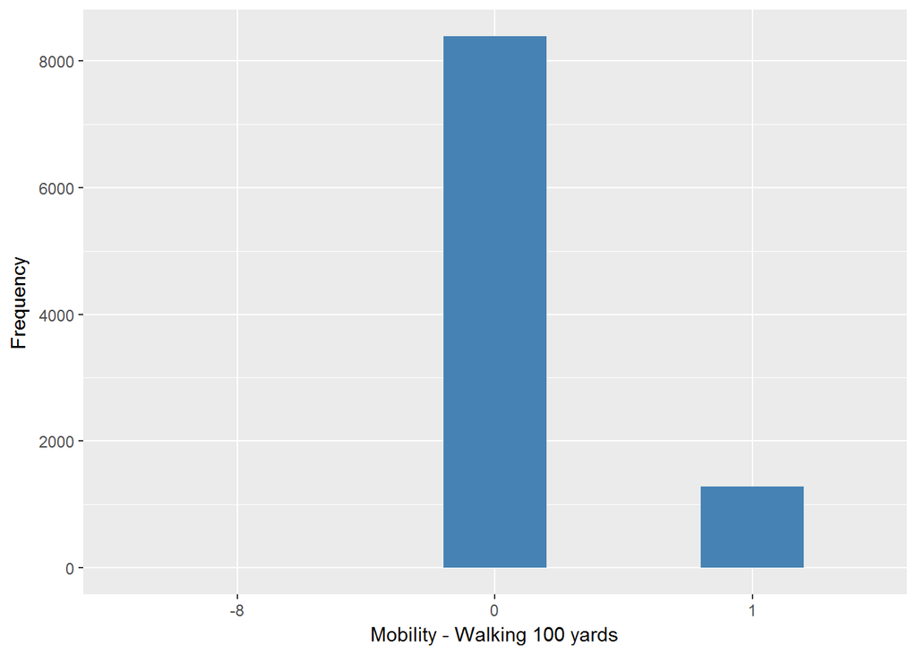

#### 2.1.7.2 Harmonisation algorithm

To compute the harmonize variable from the study-specific variable it has to be recoded as follows:

- `(hefunc==1) & (hemobwa!=1)into 1`
- `((hefunc==-9)|(hefunc==-8))&(hemobwa==0) into 1`
- `(hefunc==-9)&(hemobwa==-9) into 997`
- `(hefunc==-8)&(hemobwa==-8) into 998`
- `Otherwise<-0`

**R script:**

```r
ELSA_ds_w7 <- tibble(id = ELSA_w7_mob_walk$id)
ELSA_ds_w7$mob_walk <- rep(0, length(ELSA_w7_mob_walk$id))
ELSA_ds_w7$mob_walk[((ELSA_w7_mob_walk$HeFunc == 1) & (ELSA_w7_mob_walk$hemobwa !=
    1))] <- 1
ELSA_ds_w7$mob_walk[(((ELSA_w7_mob_walk$HeFunc == -9) | (ELSA_w7_mob_walk$HeFunc ==
    -8)) & (ELSA_w7_mob_walk$hemobwa == 0))] <- 1
ELSA_ds_w7$mob_walk[((ELSA_w7_mob_walk$HeFunc == -9) & (ELSA_w7_mob_walk$hemobwa ==
    -9))] <- 997
ELSA_ds_w7$mob_walk[((ELSA_w7_mob_walk$HeFunc == -8) & (ELSA_w7_mob_walk$hemobwa ==
    -8))] <- 998
ELSA_ds_w7$mob_walk <- labelled(ELSA_ds_w7$mob_walk, labels = c(Yes = 0, No = 1,
    Not_applicable = 996, Refuse = 997, Do_not_know = 998))
```

#### 2.1.7.3 Statistical description of the new harmonised variable

mob_walk

| Sample size | Missing values |
| --- | --- |
| 9666 | 1 |

Category

|  | 0 | 1 |
| --- | --- | --- |
| Frequency | 2745.0 | 6920.00 |
| Percentage | 28.4 | 71.59 |

Type of missing

|  | 991 | 992 | 993 | 994 | 995 | 996 | 997 | 998 | 999 | NA |
| --- | --- | --- | --- | --- | --- | --- | --- | --- | --- | --- |
| Frequency | 0 | 0 | 0 | 0 | 0 | 0 | 0 | 1.00 | 0 | 0 |
| Percentage | 0 | 0 | 0 | 0 | 0 | 0 | 0 | 0.01 | 0 | 0 |

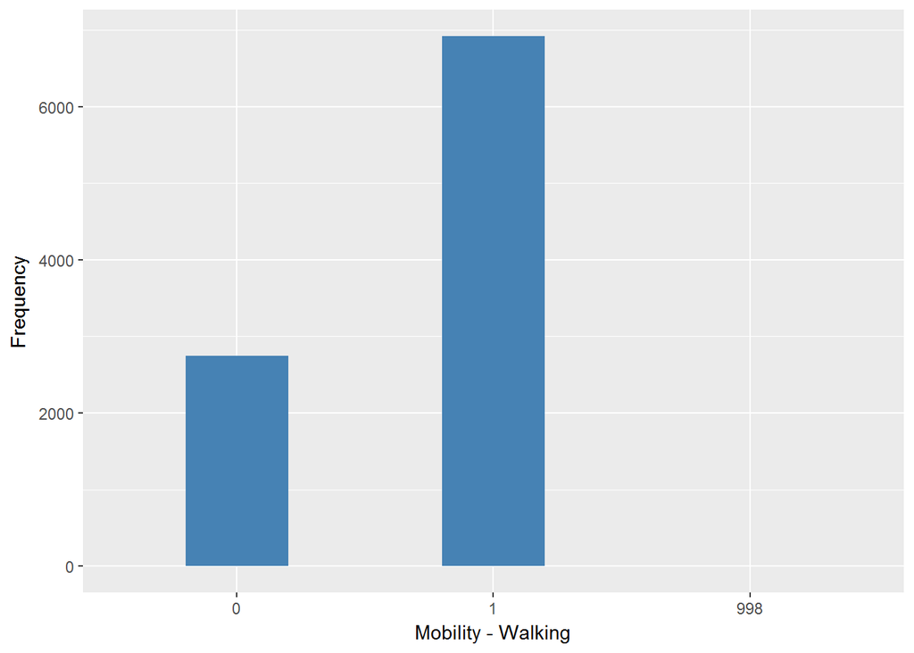

#### 2.1.7.4 Validation

|  | Otherwise -> 0 | ((hefunc=1&hemobwa!=1)\|(hefunc=-9 or -8&hemobwa=0))->1 | (hefunc=-8&hemobwa=-8)->998 |
| --- | --- | --- | --- |
| combi | 2745 | 6920 | 1 |
|  | 2745 | 6920 | 1 |

## 2.2 Summary of descriptive statistics of the harmonised variable accross populations and waves

Two tables are generated:

1. Percentages of categories in each harmonised variable.
2. Frequencies and percentages of individuals with different trajectories. To avoid too large table, Only trajectories with percentages larger than 0.3 are shown.

**R script:**

```r
ELSA_ds_w1$mob_walk <- labelled(ELSA_ds_w1$mob_walk, labels = c(Presence = 0,
    Absence = 1, Missing = 999, Do_not_know = 998, Refuse = 997, Not_applicable = 996,
    Does_not_answer = 995, Not_attempt_not_done = 994, Disable_to_measure = 993,
    Impute = 992, CAPI_interviewer_error = 991))
ELSA_ds_w2$mob_walk <- labelled(ELSA_ds_w2$mob_walk, labels = c(Presence = 0,
    Absence = 1, Missing = 999, Do_not_know = 998, Refuse = 997, Not_applicable = 996,
    Does_not_answer = 995, Not_attempt_not_done = 994, Disable_to_measure = 993,
    Impute = 992, CAPI_interviewer_error = 991))
ELSA_ds_w3$mob_walk <- labelled(ELSA_ds_w3$mob_walk, labels = c(Presence = 0,
    Absence = 1, Missing = 999, Do_not_know = 998, Refuse = 997, Not_applicable = 996,
    Does_not_answer = 995, Not_attempt_not_done = 994, Disable_to_measure = 993,
    Impute = 992, CAPI_interviewer_error = 991))
ELSA_ds_w4$mob_walk <- labelled(ELSA_ds_w4$mob_walk, labels = c(Presence = 0,
    Absence = 1, Missing = 999, Do_not_know = 998, Refuse = 997, Not_applicable = 996,
    Does_not_answer = 995, Not_attempt_not_done = 994, Disable_to_measure = 993,
    Impute = 992, CAPI_interviewer_error = 991))
ELSA_ds_w5$mob_walk <- labelled(ELSA_ds_w5$mob_walk, labels = c(Presence = 0,
    Absence = 1, Missing = 999, Do_not_know = 998, Refuse = 997, Not_applicable = 996,
    Does_not_answer = 995, Not_attempt_not_done = 994, Disable_to_measure = 993,
    Impute = 992, CAPI_interviewer_error = 991))
ELSA_ds_w6$mob_walk <- labelled(ELSA_ds_w6$mob_walk, labels = c(Presence = 0,
    Absence = 1, Missing = 999, Do_not_know = 998, Refuse = 997, Not_applicable = 996,
    Does_not_answer = 995, Not_attempt_not_done = 994, Disable_to_measure = 993,
    Impute = 992, CAPI_interviewer_error = 991))
ELSA_ds_w7$mob_walk <- labelled(ELSA_ds_w7$mob_walk, labels = c(Presence = 0,
    Absence = 1, Missing = 999, Do_not_know = 998, Refuse = 997, Not_applicable = 996,
    Does_not_answer = 995, Not_attempt_not_done = 994, Disable_to_measure = 993,
    Impute = 992, CAPI_interviewer_error = 991))

tt <- frq(ELSA_ds_w1$mob_walk)[[1]][, c(1:2, 4)]



tt[4] <- frq(ELSA_ds_w2$mob_walk)[[1]][, c(4)]
tt[5] <- frq(ELSA_ds_w3$mob_walk)[[1]][, c(4)]
tt[6] <- frq(ELSA_ds_w4$mob_walk)[[1]][, c(4)]
tt[7] <- frq(ELSA_ds_w5$mob_walk)[[1]][, c(4)]
tt[8] <- frq(ELSA_ds_w6$mob_walk)[[1]][, c(4)]
tt[9] <- frq(ELSA_ds_w7$mob_walk)[[1]][, c(4)]
tt[13, ] <- c("n", "sample size", length(ELSA_ds_w1$mob_walk), length(ELSA_ds_w2$mob_walk),
    length(ELSA_ds_w3$mob_walk), length(ELSA_ds_w4$mob_walk), length(ELSA_ds_w5$mob_walk),
    length(ELSA_ds_w6$mob_walk), length(ELSA_ds_w7$mob_walk))
names(tt) <- c("val", "label", "w1", "w2", "w3", "w4", "w5", "w6", "w7")
kable(tt)
```

| val | label | w1 | w2 | w3 | w4 | w5 | w6 | w7 |
| --- | --- | --- | --- | --- | --- | --- | --- | --- |
| 0 | Presence | 28.11 | 29.15 | 28.1 | 28.1 | 30.38 | 29.15 | 28.4 |
| 1 | Absence | 70.34 | 70.83 | 71.89 | 71.83 | 69.55 | 70.83 | 71.59 |
| 991 | CAPI_interviewer_error | 0 | 0 | 0 | 0 | 0 | 0 | 0 |
| 992 | Impute | 0 | 0 | 0 | 0 | 0 | 0 | 0 |
| 993 | Disable_to_measure | 0 | 0 | 0 | 0 | 0 | 0 | 0 |
| 994 | Not_attempt_not_done | 0 | 0 | 0 | 0 | 0 | 0 | 0 |
| 995 | Does_not_answer | 0 | 0 | 0 | 0 | 0 | 0 | 0 |
| 996 | Not_applicable | 1.45 | 0 | 0.01 | 0 | 0 | 0 | 0 |
| 997 | Refuse | 0.03 | 0.01 | 0 | 0.05 | 0.04 | 0.02 | 0 |
| 998 | Do_not_know | 0.07 | 0.01 | 0 | 0.02 | 0.03 | 0 | 0.01 |
| 999 | Missing | 0 | 0 | 0 | 0 | 0 | 0 | 0 |
| NA | NA | 0 | 0 | 0 | 0 | 0 | 0 | 0 |
| n | sample size | 12099 | 9432 | 9771 | 11050 | 10274 | 10601 | 9666 |

```r
dbb <- merge(ELSA_m_ds_w1, ELSA_m_ds_w2, by = "id", suffixes = c(".w1", ".w2"),
    all = T)
dbb <- merge(dbb, ELSA_m_ds_w3, by = "id", all = T)
dbb <- merge(dbb, ELSA_m_ds_w4, by = "id", suffixes = c(".w3", ".w4"), all = T)
dbb <- merge(dbb, ELSA_m_ds_w5, by = "id", all = T)
dbb <- merge(dbb, ELSA_m_ds_w6, by = "id", suffixes = c(".w5", ".w6"), all = T)
dbb <- merge(dbb, ELSA_m_ds_w7, by = "id", all = T)
v.dbb <- paste(dbb[, 2], dbb[, 3], dbb[, 4], dbb[, 5], dbb[, 6], dbb[, 7], dbb[,
    8], sep = "")
f.dbb <- frq(v.dbb)[[1]][, c(1, 2, 4)]
kable(f.dbb[f.dbb[, 3] >= 0.3, ])
```

|  | val | frq | raw.prc |
| --- | --- | --- | --- |
| 1 | 0000000 | 425 | 2.30 |
| 3 | 000000NA | 122 | 0.66 |
| 9 | 00000NANA | 148 | 0.80 |
| 21 | 0000NANANA | 155 | 0.84 |
| 45 | 000NANANANA | 292 | 1.58 |
| 99 | 00NANANANANA | 383 | 2.07 |
| 193 | 01NANANANANA | 72 | 0.39 |
| 245 | 0NANANANANANA | 852 | 4.61 |
| 246 | 1000000 | 77 | 0.42 |
| 284 | 100NANANANA | 77 | 0.42 |
| 342 | 10NANANANANA | 143 | 0.77 |
| 343 | 1100000 | 75 | 0.41 |
| 390 | 110NANANANA | 71 | 0.38 |
| 391 | 1110000 | 78 | 0.42 |
| 403 | 1110111 | 56 | 0.30 |
| 414 | 1111000 | 95 | 0.51 |
| 418 | 1111011 | 81 | 0.44 |
| 423 | 1111100 | 107 | 0.58 |
| 424 | 1111101 | 100 | 0.54 |
| 426 | 1111110 | 201 | 1.09 |
| 427 | 1111111 | 2238 | 12.10 |
| 428 | 111111NA | 222 | 1.20 |
| 431 | 11111NANA | 138 | 0.75 |
| 439 | 1111NANANA | 232 | 1.25 |
| 450 | 111NA111 | 55 | 0.30 |
| 460 | 111NANANANA | 395 | 2.14 |
| 479 | 11NA1111 | 63 | 0.34 |
| 507 | 11NANANANANA | 663 | 3.59 |
| 612 | 1NANANANANANA | 1149 | 6.21 |
| 671 | NANA00000 | 58 | 0.31 |
| 739 | NANA11111 | 626 | 3.39 |
| 740 | NANA1111NA | 94 | 0.51 |
| 743 | NANA111NANA | 65 | 0.35 |
| 751 | NANA11NANANA | 101 | 0.55 |
| 774 | NANA1NANANANA | 258 | 1.40 |
| 775 | NANANA0000 | 219 | 1.18 |
| 777 | NANANA000NA | 63 | 0.34 |
| 798 | NANANA0NANANA | 112 | 0.61 |
| 809 | NANANA1110 | 82 | 0.44 |
| 810 | NANANA1111 | 1114 | 6.03 |
| 811 | NANANA111NA | 139 | 0.75 |
| 814 | NANANA11NANA | 99 | 0.54 |
| 823 | NANANA1NANANA | 250 | 1.35 |
| 836 | NANANANA111 | 56 | 0.30 |
| 840 | NANANANANA00 | 101 | 0.55 |
| 844 | NANANANANA11 | 774 | 4.19 |
| 845 | NANANANANA1NA | 220 | 1.19 |
| 846 | NANANANANANA0 | 75 | 0.41 |
| 847 | NANANANANANA1 | 435 | 2.35 |
| 848 | NANANANANANANA | 89 | 0.48 |

# 3 Quality estimation